# sagt-slides

Efficiently Restructuring Sovereign Debt via Arctic Auctions with Convex Costs

SAGT 2026

| **Jugal Garg** | **Edwin Lock** | **Vijay V. Vazirani** |
| --- | --- | --- |
| University of Illinois | King’s College London | UC Irvine |

## Domestic Arrears

Example based on collaboration with Paul Klemperer and (former) IMF staff.

A country owes domestic creditors money, but **cannot repay everyone today**.

- Creditors are contractors, suppliers, pension funds, civil servants awaiting salary arrears.
- They are **heterogeneous**: claims range from small to very large.
- They differ in **patience**: some need money now, others can wait for more later.
- The country can pay from funds raised in **different years**, via revenue or borrowing.

**What, and when, to pay each creditor is a hard allocation problem.**

**Proposal:** Run an Arctic Product-Mix Auction to allocate repayments across multiple years, e.g., 2026–2030.

- Designed by Klemperer for the Icelandic Government, to exchange **blocked accounts** for other financial assets, e.g. cash or bonds.
- Belongs to the **Product-Mix Auction** family, originally designed for the Bank of England to provide liquidity to financial institutions after the 2008–9 crisis.
- More recently, IMF staff proposed using the Arctic auction for **sovereign debt restructuring**.

## An Arrears Auction

**The creditors**

- Each arrives with a budget equal to the face value of what they’re owed.
- Preferences expressed via **yield curves**: what you must pay them to wait.
- **They need not spend**: if prices are too low, they keep (part of) their claim.

|  | Budget | 2026 | 2027 | 2028 | 2029 | 2030 |
| --- | --- | --- | --- | --- | --- | --- |
| **Alice** | 400 | 100 | 106 | 112 | 120 | 127 |
| **Bob** | 650 | 100 | 115 | 130 | 140 | 150 |

What each needs in a later year to forgo 100 today — **Alice is more patient than Bob**.

**The country**

- Funds come from revenue or borrowing (e.g. IMF).
- Supplying money in a year has **increasing marginal cost**, so each year has a **cost curve** and its supply responds to price.

**Goal:** Find an efficient repayment schedule via **competitive equilibrium**. Prices are **recovery rates**.

## The Arctic product-mix auction

- We have $n$ goods (years), each available in fixed supply, and $m$ buyers (creditors)

**Buyer preferences$^*$**

- Each buyer $i$ has a budget $m_i$ and a value $u_{ij}$ for each good $j$. (Yield-curve entries are inverses of values.)
- At market prices $\mathbf{p} \in \mathbb{R}^n$, her **maximum bang per buck** is $\alpha_i = \max_j u_{ij}/p_j$.

  She demands a bundle containing only her maximum bang-per-buck goods:
  - If $\alpha_i > 1$: the bundle exhausts her budget
  - If $\alpha_i = 1$: can spend any fraction of her budget
  - If $\alpha_i < 1$: the bundle is empty

(Equivalent to demand in a quasi-linear Fisher market.)

$^*$Arctic bidders can submit multiple bids; each is a separate buyer, and allocations are summed. (Creditors can split their budget across bids with different urgencies.)

**Auctioneer**

The auctioneer specifies an increasing, convex piecewise-linear cost $c_j$ per good $j$, and maximises utility $\sum_j p_j z_j - \sum_j c_j(z_j)$ at $\mathbf{p}$ over quantities $\mathbf{z} \ge 0$.

[figure not shown]

- Costs are **separable**, so each good is optimised independently.
- At $p_j = d_{jk}$, the seller is indifferent over $[b_{j,k-1}, b_{jk}]$; for $d_{jk} < p_j < d_{j,k+1}$, he wants to sell exactly $b_{jk}$.

**Competitive equilibrium:** Prices $\mathbf{p}$ and allocation $\mathbf{x}$ such that buyers get demanded bundles, and the seller maximises utility at $\mathbf{p}$ over all $\mathbf{z} \in \mathbb{R}^n_{\ge 0}$.

## Results

Fisher markets have a special place in the AGT literature.

- **Eisenberg–Gale ’59** — convex program characterises equilibria, but not exactly computable.
- **Jain ’07** — exact equilibrium via ellipsoid + Diophantine rounding.
- **DPSV ’08** — first *combinatorial* exact algorithm; we build on its primal–dual balanced-flow machinery.
- **Orlin ’10** — first *strongly* polynomial.

Related work on Arctic auctions:

- **Fichtl ’22** — enumerates equilibria with increasing costs, but does not scale in the number of goods.
- **Vazirani ’25** — poly-time without costs, by modifying DPSV.
- **Garg–Taherijam–Vazirani ’26b** — strongly poly without costs, building on Orlin.

Does the Arctic auction **with costs** admit a rational equilibrium, and can we compute one efficiently?

**Our results**

1. If an equilibrium exists, there is one with rational prices and allocations of polynomial bit size.
2. **Main contribution**: We provide the first polynomial-time algorithm for finding competitive equilibrium.

# The Algorithm

## The expenditure network

The **expenditure network** $N(\mathbf{p}, \mathbf{m}, \mathbf{t})$ at prices $\mathbf{p}$, budgets $\mathbf{m}$ and supply $\mathbf{t}$:

[figure not shown]

(edge capacities are either labelled or are $\infty$)

Flow $f(j,i)$ is buyer $i$’s **expenditure** on good $j$. The allocated quantity is $x_{ij}=f(j,i)/p_j$.

The **surplus** of buyer $i$ is $\gamma(f)_i = m_i - f(i,t)$, the money she leaves unspent.

A **balanced flow** is a max flow minimising $\|\gamma(f)\|_2^2$, spreading surplus as equitably as possible. Efficiently computable (Darwish & Mehlhorn ’16).

## High-level overview

[figure not shown]

**Initialisation**

**Main loop**

**Post-processing**

*Our algorithm generalises DPSV’08 and Vazirani’25.*

- **Initialisation.** Start prices $\mathbf{p}$ and supply $\mathbf{t}$ at the first cost step; remove buyers who prefer to retain their budget.
- **Outer loop.** Construct expenditure network and compute its balanced flow (**primal update**).

  Stop if surplus is zero; otherwise select the buyers with most surplus and their demanded goods.
- **Inner loop.** Scale up prices of those goods until an event happens (**dual update**). Events 2–4 continue inner loop; Events 1, 5 and 6 end the **phase**.
- **Post-processing.** Find the final flow $f$, then recover allocations: $x_{ij}=f(j,i)/p_j$.

## The events

Within a phase, the algorithm increases the prices of the goods $J$ wanted by the buyers $I$ with the largest unspent budget. Several things can happen.

**A buyer changes her mind**

As goods in $J$ get pricier, outside goods become more attractive.

- **Events 2, 3.** A buyer starts demanding a good outside $J$. Fix expenditure network by adding arc.

  If she is in $I$, also recompute the balanced flow and update $I$ and $J$.

**A buyer gives up**

Bang per buck falls as prices rise; at $\alpha_i = 1$ she no longer minds walking away.

- **Event 4.** A buyer outside $I$ reaches $\alpha_i = 1$. Remove her.
- **Event 6.** A buyer *in* $I$ reaches $\alpha_i = 1$. Either remove her, or **return part of her budget** and keep her.

**The market moves**

- **Event 1.** A price reaches its next **cost breakpoint**. The seller will now supply more, so raise $t_j$.
- **Event 5.** A set of goods goes **tight**: its buyers can just afford it. End the phase.

## Correctness

After the outer loop terminates, the post-processing step rebuilds an expenditure network with **additional constraints**:

- a lower bound on how much of each good must sell,
- buyer arcs fixed at budget $m_i$.

To show the returned $(\mathbf{p},\mathbf{x})$ is a competitive equilibrium, we need three things:

1. **A feasible flow exists** in this constrained network.
2. **Buyers are happy** — each gets a bundle she demands at $\mathbf{p}$.
3. **The auctioneer is happy** — the quantity sold of each good maximises his profit at $\mathbf{p}$.

Establishing 1 and 3 is the main challenge. 2 is then almost by construction.

## Correctness — the auctioneer

**With costs**, at a marginal-cost step the seller is indifferent over an interval:

- **profitable supply** $\bar{t}_j$: the smallest profit-maximising quantity,
- **actual supply** $t_j$: the largest.

The quantity sold may lie anywhere in $[\bar{t}_j,t_j]$.

[figure not shown]

At $p_j=d_{j2}$: $\bar{t}_j=b_{j1}$ and $t_j=b_{j2}$.

Between step prices, $\bar{t}_j=t_j$.

At the final prices, construct the **lower-bounded network** $N$: source arcs bounded by $[p_j\bar{t}_j, p_jt_j]$.

Two conditions hold at termination:

- every set of **goods** has enough adjacent buyer budget to pay for its profitable supply $\bar{t}_j$ (proved by induction);
- zero surplus implies that every set of **buyers** can spend its budget on adjacent goods without exceeding actual supply $t_j$.

By **Hoffman’s circulation theorem**, these guarantee $N$ admits a feasible flow. Every good then sells $y_j \in [\bar{t}_j, t_j]$ — exactly the quantities that **maximise the auctioneer’s utility** at $\mathbf{p}$.

## Correctness — buyers

The feasible flow $f$ gives each buyer an allocation $x_{ij} = f(j,i)/p_j$.

**Buyers get their demanded bundle**

The final expenditure network guarantees:

- only max bang-per-buck arcs, so she buys the right goods;
- sink arcs fixed at $m_i$, so she spends her *current* budget exactly.

Event 6 **reduces** budgets, so a buyer might leave with less than the budget she arrived with.

- Event 6 only fires at bpb $\alpha_i = 1$.
- Bang per buck only falls as prices rise.
- So a buyer finishing with bpb $\alpha_i > 1$ has original budget.
- $\alpha_i > 1$: spends entire budget
- $\alpha_i = 1$: spends any fraction of budget
- $\alpha_i < 1$: already gone, and demands nothing

[figure not shown]

## Termination and Running Time

Define $h = m+n$, total number of cost segments $K = \sum_j K_j$, largest bid length $L$ of any input number, $M$ as sum of initial budgets.

Define same potential function as DPSV’08:

$$\Phi(f, m) = \sum_{i \in B} \left( m_i - f(i,t) \right)^2 \ \in \ [0, M^2].$$

**Lemma.** At each balanced-flow checkpoint, either $\Phi = 0$ or $\Phi \geq 2^{-O\left(h^2 (L + \log h)\right)}$.

Categorise a phase according to which event ends it.

**Phases that make progress directly**

- Type 1 advances a cost segment, at most $K$ times.
- Type 6a removes a buyer, at most $m$ times.

**Phases that decrease $\Phi$**

- Type 5 (a set goes tight): by factor $1 - 1/h^3$.
- Type 6b (a refund): by factor $1 - 1/(4h^3)$.

**Theorem 2.** For rational inputs, the algorithm uses $O\big((m+K)h^5(L+\log h)\big)$ phases, each requiring $O\big(mn(n+\log h)\big)$ max-flow computations.

## Takeaways

1. Arctic auctions remain **polynomial-time solvable** when the seller has separable, increasing piecewise-linear costs.
2. First practicable algorithms for applications in financial settings.
3. Fisher markets can admit seller-side objectives without losing tractability.
4. Our work required extending **DPSV** using new algorithmic ideas and invariants to establish correctness and polynomial running time.

**Open direction: non-separable costs.**

- Separable costs gives us per-good decomposition.
- Real constraints might couple the supply of goods: maturity targets, currency exposure, portfolio risk.
- Characterisation of equilibrium and algorithmic approaches both need new ideas.

## Thank you!

[figure not shown]

Full paper — arxiv.org/abs/2606.09631

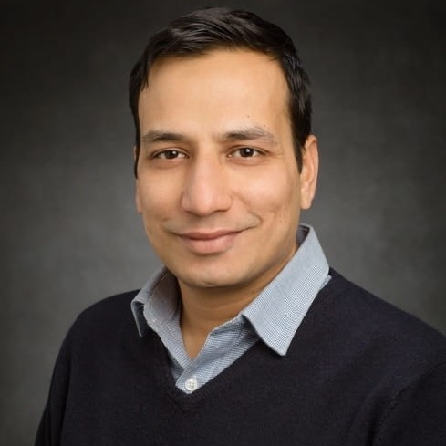

**Jugal Garg**

University of Illinois

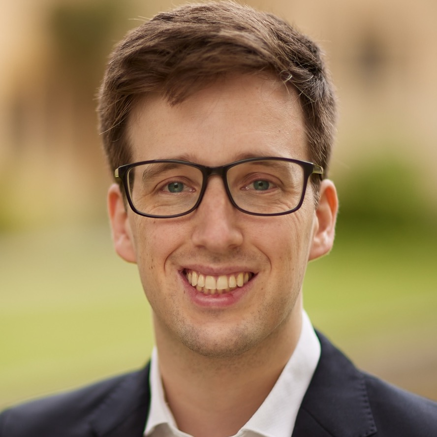

**Edwin Lock**

King’s College London

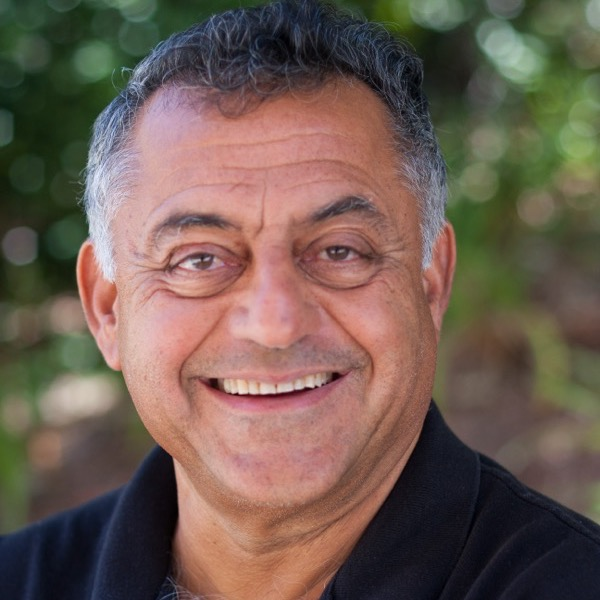

**Vijay V. Vazirani**

UC Irvine

**Reach out:** edwin.lock@kcl.ac.uk

## Bibliography

**Fisher markets and flow algorithms**

**Eisenberg & Gale (1959).** [Consensus of subjective probabilities: The pari-mutuel method](https://doi.org/10.1214/aoms/1177706369). *Annals of Mathematical Statistics* 30(1), 165–168.

**Devanur, Papadimitriou, Saberi & Vazirani (2008).** [Market equilibrium via a primal–dual algorithm for a convex program](https://doi.org/10.1145/1411509.1411512). *JACM* 55(5), Article 22.

**Jain (2007).** [A polynomial time algorithm for computing an Arrow–Debreu market equilibrium for linear utilities](https://doi.org/10.1137/S0097539705447384). *SIAM Journal on Computing* 37(1), 303–318.

**Orlin (2010).** [Improved algorithms for computing Fisher’s market clearing prices](https://doi.org/10.1145/1806689.1806731). *STOC*, 291–300.

**Darwish & Mehlhorn (2016).** [Improved balanced flow computation using parametric flow](https://doi.org/10.1016/j.ipl.2016.04.008). *Information Processing Letters* 116(9), 560–563.

**Product-mix and Arctic auctions**

**Klemperer (2018).** [Product-Mix Auctions](https://www.nuffield.ox.ac.uk/economics/Papers/2018/2018W07%20productmix.pdf). Nuffield College Economics Paper 2018-W07.

**Fichtl (2022).** [Computing Candidate Prices in Budget-Constrained Product-Mix Auctions](https://arxiv.org/abs/2208.02633). arXiv:2208.02633.

**Vazirani (2025).** [Arctic Auctions, Linear Fisher Markets, and Rational Convex Programs](https://arxiv.org/abs/2511.21637). arXiv:2511.21637.

**Garg, Lock & Vazirani (2026a).** [Efficiently Restructuring Sovereign Debt via Arctic Auctions with Convex Costs](https://arxiv.org/abs/2606.09631). SAGT 2026; arXiv:2606.09631.

**Garg, Taherijam & Vazirani (2026b).** [A Strongly Polynomial Algorithm for Arctic Auctions](https://arxiv.org/abs/2604.24756). arXiv:2604.24756.

**Baldwin, Klemperer & Lock (2026).** [Solving the “Arctic” Product-Mix Auction](https://www.edwinlock.com/pdfs/solving-arctic-pma.pdf). Preliminary draft, 14 September 2026.

# Backup slides

## The original Arctic auction

Iceland, mid-2015. Source: full version of the paper.

**The problem.** Exiting capital controls after the financial crisis. Holders of blocked **“offshore” króna** accounts — foreign-owned ISK positions — had balances trapped in the country.

**The proposal.** An auction to exchange trapped króna for alternative assets: cash, or government bonds in ISK or euros.

Account holders express preferences over asset bundles in a **single mechanism**, with prices emerging endogenously.

**Why costs matter.** The government wanted to adjust the quantity and composition of assets supplied *in response to bids*, subject to its own supply preferences and costs.

**One caveat.** It also wished to retain the option of exerting **monopsonistic power**, so it did not limit itself to competitive equilibrium.

**What happened.** After the 2016 Panama Papers turmoil and a change of government, the auction was dropped. Most offshore accounts were unblocked by other means.